# USOC DataAnalysis Project by Nicholas Anthony

```python
import pandas as pd
import matplotlib.pyplot as plt
from datetime import datetime

wellness = pd.read_csv("MockWellness.csv")
wellness.Date = pd.to_datetime(wellness.Date)
loaded = pd.read_csv("MockLoad.csv")
loaded.Date = pd.to_datetime(loaded.Date)
```

## Athlete Compliance

Athletes were 100% compliant in completing the wellness suyrvey. The table below shows the missing values out of 1279 total entries.

```python
wellness.isnull().sum(axis=0)
```

```
Date                  0
Athlete               0
Team                  0
Weekday               0
Sleep Hours           0
Sleep Quality         0
Mood                  0
Readiness to Train    0
Soreness              0
Stress                0
Fatigue               0
dtype: int64
```

Unfortunately, compliance is much lower for the Load survey. Despite 983 entries being made, compliance was below 50% for most fields. Athletes leaving fields blank may be due to the field not applying to them at that time (i.e. injuries, travel hours, competitions, etc.). To avoid missing data, it would be helpful to install a default value for these fields. However, lack of compliance (with more than 50% missing data) for all the practice/conditioning/strength fields except practice load and practice is evident. This could be due to not conducting strength/conditioning training sessions daily, resulting in no data being input by the athlete. Similar activity is reported for each type of exercise (strength, conditioning, practice).

```python
loaded.isnull().sum(axis=0)
```

```
Date                                         0
Weekday                                      0
Athlete                                      0
Team                                         0
Injury/Illness Status                        0
Training Availability                        0
Injury First Time Report                     0
Injury Type                                965
Training/NoTraining                          0
Training Location                          382
Travel/No Travel                             0
Travel Hours                               905
Travel Difficulty                          911
Competition RPE                            920
Competition Duration                       920
Competition Load                           920
Conditioning Load                          857
Conditioning Duration                      856
Conditioning RPE                           857
Practice Load                                0
Practice Duration                            0
Practice RPE                               550
Strength Load                              599
Strength Duration                          595
Strength RPE                               599
Competition Perceived Performance          928
Conditioning Perceived Performance         867
Practice Perceived Performance             614
Strength Training Perceived Performance    650
Recovery Modality                            0
dtype: int64
```

### Data Verification

The collected values for both surveys appear as valid responses.

```python
wellness.describe()
```

|  | Sleep Hours | Sleep Quality | Mood | Readiness to Train | Soreness | Stress | Fatigue |
| --- | --- | --- | --- | --- | --- | --- | --- |
| count | 1279.000000 | 1279.000000 | 1279.000000 | 1279.000000 | 1279.000000 | 1279.000000 | 1279.000000 |
| mean | 7.868569 | 6.925723 | 7.151681 | 5.715403 | 3.227522 | 2.062549 | 3.312744 |
| std | 1.692905 | 2.153344 | 1.983613 | 3.454195 | 2.277465 | 2.121688 | 2.312939 |
| min | 0.000000 | 0.000000 | 0.000000 | 0.000000 | 0.000000 | 0.000000 | 0.000000 |
| 25% | 7.000000 | 6.000000 | 6.000000 | 3.000000 | 2.000000 | 0.000000 | 2.000000 |
| 50% | 8.000000 | 7.000000 | 7.000000 | 6.000000 | 3.000000 | 2.000000 | 3.000000 |
| 75% | 9.000000 | 8.000000 | 9.000000 | 9.000000 | 5.000000 | 3.000000 | 5.000000 |
| max | 14.000000 | 10.000000 | 10.000000 | 10.000000 | 10.000000 | 10.000000 | 10.000000 |

```python
loaded.describe()
```

|  | Training Availability | Travel Hours | Travel Difficulty | Competition RPE | Competition Duration | Competition Load | Conditioning Load | Conditioning Duration | Conditioning RPE | Practice Load | Practice Duration | Practice RPE | Strength Load | Strength Duration | Strength RPE | Competition Perceived Performance | Conditioning Perceived Performance | Practice Perceived Performance | Strength Training Perceived Performance |
| --- | --- | --- | --- | --- | --- | --- | --- | --- | --- | --- | --- | --- | --- | --- | --- | --- | --- | --- | --- |
| count | 983.000000 | 78.000000 | 72.000000 | 63.000000 | 63.000000 | 63.000000 | 126.000000 | 127.000000 | 126.000000 | 983.000000 | 983.000000 | 433.000000 | 384.000000 | 388.00000 | 384.000000 | 55.000000 | 116.000000 | 369.000000 | 333.000000 |
| mean | 97.440488 | 11.846154 | 4.236111 | 6.666667 | 53.968254 | 376.746032 | 272.230159 | 40.244094 | 6.682540 | 210.501526 | 39.780264 | 4.424942 | 285.486979 | 59.10567 | 4.742188 | 7.236364 | 7.948276 | 7.341463 | 8.027027 |
| std | 11.645138 | 7.087719 | 2.405938 | 1.534548 | 25.307125 | 206.012759 | 153.981722 | 19.686720 | 1.912698 | 292.271952 | 51.624156 | 1.821814 | 109.718343 | 12.06257 | 1.453794 | 1.574844 | 1.553928 | 1.609226 | 1.297306 |
| min | 22.000000 | 1.000000 | 0.000000 | 3.000000 | 5.000000 | 15.000000 | 1.000000 | 1.000000 | 1.000000 | 0.000000 | 0.000000 | 0.000000 | 0.000000 | 0.00000 | 1.000000 | 4.000000 | 4.000000 | 1.000000 | 3.000000 |
| 25% | 100.000000 | 7.000000 | 2.000000 | 6.000000 | 35.000000 | 210.000000 | 168.000000 | 30.000000 | 5.250000 | 0.000000 | 0.000000 | 3.000000 | 236.000000 | 59.00000 | 4.000000 | 6.000000 | 7.000000 | 6.000000 | 7.000000 |
| 50% | 100.000000 | 8.000000 | 4.000000 | 7.000000 | 70.000000 | 420.000000 | 244.500000 | 39.000000 | 7.000000 | 0.000000 | 0.000000 | 4.000000 | 280.000000 | 60.00000 | 5.000000 | 7.000000 | 8.000000 | 7.000000 | 8.000000 |
| 75% | 100.000000 | 20.000000 | 6.000000 | 8.000000 | 70.000000 | 490.000000 | 357.500000 | 45.000000 | 8.000000 | 403.500000 | 64.000000 | 6.000000 | 360.000000 | 60.00000 | 6.000000 | 8.000000 | 9.000000 | 8.000000 | 9.000000 |
| max | 100.000000 | 24.000000 | 10.000000 | 9.000000 | 100.000000 | 900.000000 | 800.000000 | 115.000000 | 10.000000 | 1206.000000 | 243.000000 | 10.000000 | 658.000000 | 119.00000 | 9.000000 | 10.000000 | 10.000000 | 10.000000 | 10.000000 |

Comparing the teams Wellness sruveys by averages and variance shows great similarities between the groups.

```python
w_teams = wellness.groupby('Team').mean()
w_teams
```

| Team | Sleep Hours | Sleep Quality | Mood | Readiness to Train | Soreness | Stress | Fatigue |
| --- | --- | --- | --- | --- | --- | --- | --- |
| Team 1 | 7.817628 | 6.937500 | 7.076923 | 5.730769 | 3.171474 | 1.794872 | 3.217949 |
| Team 2 | 7.917099 | 6.914504 | 7.222901 | 5.700763 | 3.280916 | 2.317557 | 3.403053 |

```python
w_teams.describe()
```

|  | Sleep Hours | Sleep Quality | Mood | Readiness to Train | Soreness | Stress | Fatigue |
| --- | --- | --- | --- | --- | --- | --- | --- |
| count | 2.000000 | 2.000000 | 2.000000 | 2.000000 | 2.000000 | 2.000000 | 2.000000 |
| mean | 7.867364 | 6.926002 | 7.149912 | 5.715766 | 3.226195 | 2.056215 | 3.310501 |
| std | 0.070337 | 0.016261 | 0.103222 | 0.021217 | 0.077387 | 0.369594 | 0.130889 |
| min | 7.817628 | 6.914504 | 7.076923 | 5.700763 | 3.171474 | 1.794872 | 3.217949 |
| 25% | 7.842496 | 6.920253 | 7.113417 | 5.708265 | 3.198835 | 1.925543 | 3.264225 |
| 50% | 7.867364 | 6.926002 | 7.149912 | 5.715766 | 3.226195 | 2.056215 | 3.310501 |
| 75% | 7.892231 | 6.931751 | 7.186406 | 5.723268 | 3.253556 | 2.186886 | 3.356777 |
| max | 7.917099 | 6.937500 | 7.222901 | 5.730769 | 3.280916 | 2.317557 | 3.403053 |

```python
w_athletes = wellness.groupby('Athlete').mean().sort_values(by=['Athlete'])
w_athletes
```

| Athlete | Sleep Hours | Sleep Quality | Mood | Readiness to Train | Soreness | Stress | Fatigue |
| --- | --- | --- | --- | --- | --- | --- | --- |
| Athlete 1 | 8.325333 | 6.400000 | 5.866667 | 5.040000 | 2.253333 | 1.360000 | 4.546667 |
| Athlete 10 | 8.020896 | 7.850746 | 7.850746 | 3.597015 | 2.164179 | 0.432836 | 1.671642 |
| Athlete 11 | 8.364474 | 8.526316 | 8.473684 | 6.842105 | 3.328947 | 2.368421 | 4.000000 |
| Athlete 12 | 8.188889 | 6.763889 | 6.916667 | 4.944444 | 3.486111 | 1.430556 | 3.069444 |
| Athlete 13 | 6.883099 | 5.352113 | 5.676056 | 4.577465 | 3.394366 | 3.957746 | 4.647887 |
| Athlete 14 | 8.200000 | 6.666667 | 6.333333 | 8.333333 | 4.666667 | 2.000000 | 5.000000 |
| Athlete 15 | 7.849231 | 8.061538 | 9.169231 | 5.153846 | 1.569231 | 0.507692 | 0.230769 |
| Athlete 16 | 8.923611 | 7.402778 | 7.777778 | 7.722222 | 2.444444 | 2.305556 | 2.777778 |
| Athlete 17 | 7.580556 | 7.625000 | 8.791667 | 6.611111 | 4.194444 | 1.638889 | 3.736111 |
| Athlete 18 | 8.113889 | 5.513889 | 5.902778 | 3.763889 | 3.916667 | 2.472222 | 4.722222 |
| Athlete 19 | 7.923750 | 7.125000 | 6.812500 | 6.162500 | 5.037500 | 4.037500 | 5.387500 |
| Athlete 2 | 7.336364 | 8.363636 | 8.363636 | 7.909091 | 0.545455 | 0.181818 | 0.727273 |
| Athlete 20 | 7.373770 | 5.393443 | 5.180328 | 4.754098 | 1.950820 | 2.098361 | 1.573770 |
| Athlete 3 | 6.445455 | 6.688312 | 7.012987 | 4.233766 | 3.129870 | 3.077922 | 4.207792 |
| Athlete 4 | 8.695082 | 6.950820 | 7.065574 | 6.180328 | 4.344262 | 4.000000 | 4.278689 |
| Athlete 5 | 8.598437 | 7.718750 | 7.562500 | 4.937500 | 3.671875 | 3.312500 | 3.578125 |
| Athlete 6 | 6.464286 | 4.942857 | 4.942857 | 5.342857 | 2.342857 | 0.342857 | 1.557143 |
| Athlete 7 | 7.408824 | 7.117647 | 7.323529 | 5.323529 | 3.220588 | 0.000000 | 2.779412 |
| Athlete 8 | 8.583582 | 5.910448 | 6.701493 | 8.149254 | 5.970149 | 4.029851 | 5.835821 |
| Athlete 9 | 8.106667 | 8.853333 | 9.360000 | 8.746667 | 1.880000 | 0.026667 | 0.693333 |

```python
w_athletes.describe()
```

|  | Sleep Hours | Sleep Quality | Mood | Readiness to Train | Soreness | Stress | Fatigue |
| --- | --- | --- | --- | --- | --- | --- | --- |
| count | 20.000000 | 20.000000 | 20.000000 | 20.000000 | 20.000000 | 20.000000 | 20.000000 |
| mean | 7.869310 | 6.961359 | 7.154201 | 5.916251 | 3.175588 | 1.979070 | 3.251069 |
| std | 0.704926 | 1.126105 | 1.280523 | 1.580472 | 1.310865 | 1.431511 | 1.680586 |
| min | 6.445455 | 4.942857 | 4.942857 | 3.597015 | 0.545455 | 0.000000 | 0.230769 |
| 25% | 7.400060 | 6.277612 | 6.225694 | 4.891650 | 2.231045 | 0.488978 | 1.647174 |
| 50% | 8.063781 | 7.034233 | 7.039280 | 5.333193 | 3.274768 | 2.049180 | 3.657118 |
| 75% | 8.335118 | 7.751749 | 7.978969 | 7.062135 | 3.986111 | 3.136567 | 4.571972 |
| max | 8.923611 | 8.853333 | 9.360000 | 8.746667 | 5.970149 | 4.037500 | 5.835821 |

Comparing the Load surveys per team averages shows large variance in competition duration/load and strength load between the teams. Team 2 having higher values for all three fields suggesting they had a different training/competition schedule during this time period.

```python
l_teams = loaded.groupby('Team').mean()
l_teams
```

| Team | Training Availability | Travel Hours | Travel Difficulty | Competition RPE | Competition Duration | Competition Load | Conditioning Load | Conditioning Duration | Conditioning RPE | Practice Load | Practice Duration | Practice RPE | Strength Load | Strength Duration | Strength RPE | Competition Perceived Performance | Conditioning Perceived Performance | Practice Perceived Performance | Strength Training Perceived Performance |
| --- | --- | --- | --- | --- | --- | --- | --- | --- | --- | --- | --- | --- | --- | --- | --- | --- | --- | --- | --- |
| Team 1 | 98.035270 | 10.711111 | 4.325581 | 6.593750 | 49.062500 | 336.250000 | 272.701754 | 40.350877 | 6.508772 | 213.647303 | 40.620332 | 4.241860 | 277.594595 | 58.015957 | 4.718919 | 7.28 | 7.760000 | 7.352601 | 7.993631 |
| Team 2 | 96.868263 | 13.393939 | 4.103448 | 6.741935 | 59.032258 | 418.548387 | 271.840580 | 40.157143 | 6.826087 | 207.475050 | 38.972056 | 4.605505 | 292.824121 | 60.130000 | 4.763819 | 7.20 | 8.090909 | 7.331633 | 8.056818 |

```python
l_teams.describe()
```

|  | Training Availability | Travel Hours | Travel Difficulty | Competition RPE | Competition Duration | Competition Load | Conditioning Load | Conditioning Duration | Conditioning RPE | Practice Load | Practice Duration | Practice RPE | Strength Load | Strength Duration | Strength RPE | Competition Perceived Performance | Conditioning Perceived Performance | Practice Perceived Performance | Strength Training Perceived Performance |
| --- | --- | --- | --- | --- | --- | --- | --- | --- | --- | --- | --- | --- | --- | --- | --- | --- | --- | --- | --- |
| count | 2.000000 | 2.000000 | 2.000000 | 2.000000 | 2.000000 | 2.000000 | 2.000000 | 2.000000 | 2.000000 | 2.000000 | 2.000000 | 2.000000 | 2.000000 | 2.000000 | 2.000000 | 2.000000 | 2.000000 | 2.000000 | 2.000000 |
| mean | 97.451767 | 12.052525 | 4.214515 | 6.667843 | 54.047379 | 377.399194 | 272.271167 | 40.254010 | 6.667429 | 210.561176 | 39.796194 | 4.423683 | 285.209358 | 59.072979 | 4.741369 | 7.240000 | 7.925455 | 7.342117 | 8.025224 |
| std | 0.825198 | 1.897046 | 0.157072 | 0.104783 | 7.049684 | 58.193748 | 0.608942 | 0.136991 | 0.224376 | 4.364442 | 1.165507 | 0.257135 | 10.768901 | 1.494854 | 0.031749 | 0.056569 | 0.233988 | 0.014827 | 0.044680 |
| min | 96.868263 | 10.711111 | 4.103448 | 6.593750 | 49.062500 | 336.250000 | 271.840580 | 40.157143 | 6.508772 | 207.475050 | 38.972056 | 4.241860 | 277.594595 | 58.015957 | 4.718919 | 7.200000 | 7.760000 | 7.331633 | 7.993631 |
| 25% | 97.160015 | 11.381818 | 4.158982 | 6.630796 | 51.554940 | 356.824597 | 272.055873 | 40.205576 | 6.588101 | 209.018113 | 39.384125 | 4.332771 | 281.401976 | 58.544468 | 4.730144 | 7.220000 | 7.842727 | 7.336875 | 8.009427 |
| 50% | 97.451767 | 12.052525 | 4.214515 | 6.667843 | 54.047379 | 377.399194 | 272.271167 | 40.254010 | 6.667429 | 210.561176 | 39.796194 | 4.423683 | 285.209358 | 59.072979 | 4.741369 | 7.240000 | 7.925455 | 7.342117 | 8.025224 |
| 75% | 97.743518 | 12.723232 | 4.270048 | 6.704889 | 56.539819 | 397.973790 | 272.486461 | 40.302444 | 6.746758 | 212.104240 | 40.208263 | 4.514594 | 289.016739 | 59.601489 | 4.752594 | 7.260000 | 8.008182 | 7.347359 | 8.041021 |
| max | 98.035270 | 13.393939 | 4.325581 | 6.741935 | 59.032258 | 418.548387 | 272.701754 | 40.350877 | 6.826087 | 213.647303 | 40.620332 | 4.605505 | 292.824121 | 60.130000 | 4.763819 | 7.280000 | 8.090909 | 7.352601 | 8.056818 |

Similar analyses for Load surveys per athlete reveals the variety of training schedules for each individual athlete as evident by the variance in each athletes type of exercise (conditioning, competition, strength) load and duration. Interestingly, 100% of all surveys contained data on recovery modality.

```python
l_athletes = loaded.groupby('Athlete').mean().sort_values(by=['Athlete'])
l_athletes
```

| Athlete | Training Availability | Travel Hours | Travel Difficulty | Competition RPE | Competition Duration | Competition Load | Conditioning Load | Conditioning Duration | Conditioning RPE | Practice Load | Practice Duration | Practice RPE | Strength Load | Strength Duration | Strength RPE | Competition Perceived Performance | Conditioning Perceived Performance | Practice Perceived Performance | Strength Training Perceived Performance |
| --- | --- | --- | --- | --- | --- | --- | --- | --- | --- | --- | --- | --- | --- | --- | --- | --- | --- | --- | --- |
| Athlete 1 | 97.014925 | 11.000000 | 4.833333 | 8.000000 | 53.000000 | 418.000000 | 204.166667 | 33.333333 | 5.833333 | 240.820896 | 44.402985 | 4.441176 | 252.240000 | 57.960000 | 4.320000 | 6.400000 | NaN | 6.526316 | 6.636364 |
| Athlete 10 | 100.000000 | 11.750000 | 5.857143 | 5.200000 | 13.000000 | 76.000000 | 270.529412 | 40.705882 | 6.588235 | 299.586667 | 48.986667 | 4.842105 | 303.906250 | 56.666667 | 5.218750 | 8.200000 | 8.352941 | 7.432432 | 8.454545 |
| Athlete 11 | 100.000000 | 13.750000 | 4.000000 | 8.400000 | 76.000000 | 642.000000 | 252.000000 | 31.333333 | 8.000000 | 260.081967 | 41.295082 | 5.250000 | 340.304348 | 56.708333 | 5.826087 | 7.600000 | 8.333333 | 7.923077 | 8.304348 |
| Athlete 12 | 100.000000 | NaN | NaN | 7.500000 | 68.750000 | 525.000000 | 326.600000 | 39.000000 | 8.200000 | 179.944444 | 38.361111 | 4.406250 | 218.633333 | 59.400000 | 3.666667 | 7.250000 | 7.600000 | 7.600000 | 7.758621 |
| Athlete 13 | 100.000000 | 11.333333 | 4.333333 | 5.750000 | 46.250000 | 285.000000 | 187.333333 | 41.833333 | 4.000000 | 189.640625 | 38.437500 | 4.200000 | 189.307692 | 58.884615 | 3.153846 | 5.666667 | 5.500000 | 5.764706 | 6.071429 |
| Athlete 14 | 100.000000 | NaN | NaN | 3.500000 | 70.000000 | 245.000000 | 244.000000 | 61.000000 | 4.000000 | 272.666667 | 70.666667 | 2.750000 | 212.000000 | 60.500000 | 3.500000 | 7.500000 | 9.000000 | 9.000000 | 9.500000 |
| Athlete 15 | 97.192308 | 9.000000 | NaN | 5.000000 | 70.000000 | 350.000000 | 350.600000 | 61.400000 | 5.400000 | 351.730769 | 84.538462 | 3.733333 | 250.900000 | 67.500000 | 3.700000 | 4.000000 | 4.800000 | 5.666667 | 6.000000 |
| Athlete 16 | 76.446809 | 4.500000 | 1.000000 | NaN | NaN | NaN | 277.300000 | 39.904762 | 7.150000 | 80.617021 | 10.297872 | 7.000000 | 373.150000 | 52.950000 | 6.600000 | NaN | 8.904762 | 8.777778 | 8.263158 |
| Athlete 17 | 97.138462 | 21.000000 | 4.400000 | 6.200000 | 31.000000 | 201.000000 | 313.666667 | 42.833333 | 7.166667 | 208.661538 | 35.200000 | 4.629630 | 241.608696 | 56.869565 | 4.173913 | 7.000000 | 7.833333 | 6.125000 | 8.000000 |
| Athlete 18 | 98.931507 | 14.000000 | 3.500000 | 6.500000 | 43.750000 | 322.500000 | 309.272727 | 38.000000 | 7.909091 | 187.589041 | 39.054795 | 3.941176 | 253.458333 | 55.333333 | 4.500000 | 6.750000 | 9.363636 | 7.333333 | 9.375000 |
| Athlete 19 | 100.000000 | 14.700000 | 5.555556 | 7.500000 | 75.000000 | 565.000000 | 201.250000 | 28.625000 | 7.000000 | 254.675325 | 41.766234 | 5.200000 | 431.571429 | 69.971429 | 6.171429 | 8.500000 | 8.142857 | 8.571429 | 8.454545 |
| Athlete 2 | 100.000000 | NaN | NaN | NaN | NaN | NaN | 7.000000 | 1.000000 | 7.000000 | 258.333333 | 53.833333 | 4.750000 | 214.333333 | 58.666667 | 3.666667 | NaN | NaN | 5.333333 | NaN |
| Athlete 20 | 68.750000 | NaN | NaN | NaN | NaN | NaN | 266.666667 | 53.333333 | 5.000000 | 0.000000 | 0.000000 | NaN | 393.333333 | 78.666667 | 5.000000 | NaN | 7.333333 | NaN | 7.666667 |
| Athlete 3 | 95.367347 | 8.200000 | 2.333333 | 7.333333 | 71.666667 | 525.000000 | NaN | NaN | NaN | 186.244898 | 35.448980 | 4.272727 | 226.583333 | 54.416667 | 4.000000 | 6.000000 | NaN | 7.238095 | 8.636364 |
| Athlete 4 | 100.000000 | NaN | NaN | NaN | NaN | NaN | 270.000000 | 30.000000 | 9.000000 | 120.400000 | 33.000000 | 3.666667 | 295.000000 | 59.000000 | 5.000000 | NaN | 4.000000 | 6.666667 | 8.000000 |
| Athlete 5 | 97.842857 | 5.888889 | 5.555556 | 8.000000 | 70.000000 | 560.000000 | 337.666667 | 42.333333 | 7.750000 | 191.371429 | 37.414286 | 4.068966 | 304.200000 | 59.080000 | 5.120000 | 8.000000 | 7.500000 | 6.931034 | 7.960000 |
| Athlete 6 | 100.000000 | 15.111111 | 3.555556 | 6.777778 | 70.000000 | 474.444444 | 455.250000 | 62.750000 | 5.750000 | 208.371429 | 37.528571 | 4.413793 | 289.250000 | 57.285714 | 4.928571 | 5.750000 | 5.666667 | 5.857143 | 6.000000 |
| Athlete 7 | 97.215385 | NaN | NaN | 5.000000 | 58.333333 | 291.666667 | 241.000000 | 38.000000 | 6.666667 | 189.446154 | 47.600000 | 3.333333 | 250.035714 | 59.758621 | 4.214286 | 10.000000 | 8.833333 | 9.178571 | 9.071429 |
| Athlete 8 | 98.310811 | 17.000000 | 4.333333 | 6.000000 | 32.500000 | 215.000000 | 193.727273 | 35.545455 | 5.363636 | 159.189189 | 29.662162 | 4.307692 | 284.354839 | 59.218750 | 4.741935 | 7.000000 | 7.454545 | 6.880000 | 7.625000 |
| Athlete 9 | 91.000000 | NaN | NaN | 7.500000 | 10.000000 | 75.000000 | NaN | NaN | NaN | 367.142857 | 70.428571 | 3.500000 | 263.333333 | 55.666667 | 4.666667 | 8.000000 | NaN | 7.500000 | 8.333333 |

```python
l_athletes.describe()
```

|  | Training Availability | Travel Hours | Travel Difficulty | Competition RPE | Competition Duration | Competition Load | Conditioning Load | Conditioning Duration | Conditioning RPE | Practice Load | Practice Duration | Practice RPE | Strength Load | Strength Duration | Strength RPE | Competition Perceived Performance | Conditioning Perceived Performance | Practice Perceived Performance | Strength Training Perceived Performance |
| --- | --- | --- | --- | --- | --- | --- | --- | --- | --- | --- | --- | --- | --- | --- | --- | --- | --- | --- | --- |
| count | 20.000000 | 13.000000 | 12.000000 | 16.000000 | 16.000000 | 16.000000 | 18.000000 | 18.000000 | 18.000000 | 20.000000 | 20.000000 | 19.000000 | 20.000000 | 20.000000 | 20.000000 | 16.000000 | 16.000000 | 19.000000 | 19.000000 |
| mean | 95.760520 | 12.094872 | 4.104762 | 6.510069 | 53.703125 | 360.663194 | 261.557190 | 40.051728 | 6.543202 | 210.325712 | 41.896164 | 4.352992 | 279.375198 | 59.725185 | 4.608441 | 7.101042 | 7.413671 | 7.173978 | 7.900569 |
| std | 8.321493 | 4.550248 | 1.396709 | 1.365589 | 22.015777 | 176.194247 | 91.891530 | 14.369866 | 1.425920 | 85.572547 | 18.963714 | 0.897232 | 64.221073 | 5.953622 | 0.909290 | 1.389531 | 1.596712 | 1.157721 | 1.056262 |
| min | 68.750000 | 4.500000 | 1.000000 | 3.500000 | 10.000000 | 75.000000 | 7.000000 | 1.000000 | 4.000000 | 0.000000 | 0.000000 | 2.750000 | 189.307692 | 52.950000 | 3.153846 | 4.000000 | 4.000000 | 5.333333 | 6.000000 |
| 25% | 97.107577 | 9.000000 | 3.541667 | 5.612500 | 40.937500 | 237.500000 | 213.375000 | 33.886364 | 5.487500 | 184.669785 | 35.386735 | 3.837255 | 237.852355 | 56.697917 | 3.925000 | 6.300000 | 6.916667 | 6.325658 | 7.645833 |
| 50% | 98.621159 | 11.750000 | 4.333333 | 6.638889 | 63.541667 | 336.250000 | 268.333333 | 39.452381 | 6.833333 | 199.871429 | 38.746147 | 4.307692 | 258.395833 | 58.775641 | 4.583333 | 7.125000 | 7.716667 | 7.238095 | 8.000000 |
| 75% | 100.000000 | 14.700000 | 5.013889 | 7.500000 | 70.000000 | 525.000000 | 312.568182 | 42.708333 | 7.604167 | 258.770492 | 47.946667 | 4.689815 | 303.979688 | 59.489655 | 5.030000 | 8.000000 | 8.473039 | 7.761538 | 8.454545 |
| max | 100.000000 | 21.000000 | 5.857143 | 8.400000 | 76.000000 | 642.000000 | 455.250000 | 62.750000 | 9.000000 | 367.142857 | 84.538462 | 7.000000 | 431.571429 | 78.666667 | 6.600000 | 10.000000 | 9.363636 | 9.178571 | 9.500000 |

## Engaging Athletes Strategy

In order to further motivate athletes to complete the surveys I suggest utilizing John Keller's ARCS model of learning (Keller, 1987). *citation below, article attached*

The ARCS model is based upon four foundational prinicples of motivation: Attention, Releveance, Confidence, and Satisfaction. While developed for students, the theory is easily transferable to athletes. Coaches can easily bring attention to the issue by taking a few minutes after a workout to fill out the surveys. This could result in some data-contamination; however, if the coach takes it seriously and encourages honesty there shouldn't be a problem. These surveys directly relate to these athletes. Perhaps explicitly stating how their responses will affect furture training schedules would be another good step to reinforce the relevance of the task. Allowing athletes to build confidence in filling out surveys may seem strange. However, it is confidence in the survey and what it means that should be focused on. For example, sitting down with an athlete and explaining the factors that lead to a more positive performance experience (i.e. sleep, fatigue, stress, etc.) and checking in regularly to make sure the athlete is following the plan to control those factors will allow the athlete to build confidence by knowing they are properly preparing themselves to perform well. Satisfaction will come when an athlete follows the factor-control plan and experiences (or should experience) postive performances or percieved performance.

Finally, I would reccomend developing a mobile application so that the surveys can be filled out as soon as possible after a workout as opposed to at the end of the day (or even the next day). This would reduce data collection and entry times as well as be more user friendly. Furthermore, this would make the Load survey quite shorter as each athlete could have an account linked to their status and they would simply be filling out fields related to their current activity (travel, strength, conditioning, competition) or roughly five fields as opposed to the current 30. An alarm could also be set to alert the athletes to fill out the Wellness survey each day at a specified time.

Keller, J. M. (1987). Development and use of the ARCS model of instructional design. Journal of instructional development, 10(3), 2.

## The Story of Athlete 11

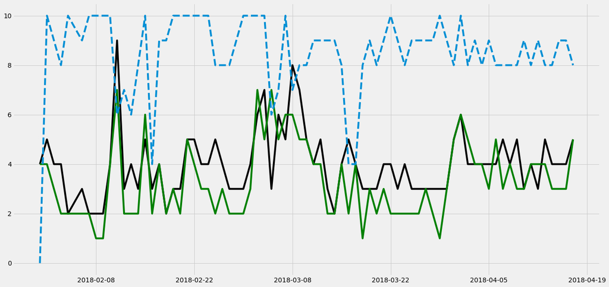

```python
plt.rcParams['figure.figsize']=(20,10)
plt.style.use('fivethirtyeight')

wellness1 = wellness[wellness['Athlete'] == 'Athlete 11']
loaded1 = loaded[loaded['Athlete'] == 'Athlete 11']

p1 = plt.plot(wellness1.Date, wellness1['Fatigue'], 'black')
p2 = plt.plot(wellness1.Date, wellness1['Soreness'], 'green')
p3 = plt.plot(wellness1.Date, wellness1['Mood'], '--')
```

```python
wellness1.describe()
```

|  | Sleep Hours | Sleep Quality | Mood | Readiness to Train | Soreness | Stress | Fatigue |
| --- | --- | --- | --- | --- | --- | --- | --- |
| count | 76.000000 | 76.000000 | 76.000000 | 76.000000 | 76.000000 | 76.000000 | 76.00000 |
| mean | 8.364474 | 8.526316 | 8.473684 | 6.842105 | 3.328947 | 2.368421 | 4.00000 |
| std | 1.351809 | 1.700774 | 1.700774 | 3.986820 | 1.491202 | 1.030755 | 1.32665 |
| min | 4.800000 | 0.000000 | 0.000000 | 0.000000 | 1.000000 | 1.000000 | 2.00000 |
| 25% | 7.575000 | 8.000000 | 8.000000 | 4.000000 | 2.000000 | 2.000000 | 3.00000 |
| 50% | 8.350000 | 9.000000 | 9.000000 | 9.500000 | 3.000000 | 2.000000 | 4.00000 |
| 75% | 9.100000 | 10.000000 | 10.000000 | 10.000000 | 4.000000 | 3.000000 | 5.00000 |
| max | 13.000000 | 10.000000 | 10.000000 | 10.000000 | 7.000000 | 5.000000 | 9.00000 |

```python
loaded1.describe()
```

|  | Training Availability | Travel Hours | Travel Difficulty | Competition RPE | Competition Duration | Competition Load | Conditioning Load | Conditioning Duration | Conditioning RPE | Practice Load | Practice Duration | Practice RPE | Strength Load | Strength Duration | Strength RPE | Competition Perceived Performance | Conditioning Perceived Performance | Practice Perceived Performance | Strength Training Perceived Performance |
| --- | --- | --- | --- | --- | --- | --- | --- | --- | --- | --- | --- | --- | --- | --- | --- | --- | --- | --- | --- |
| count | 61.0 | 4.000000 | 4.00000 | 5.000000 | 5.000000 | 5.000000 | 3.000000 | 3.000000 | 3.000000 | 61.000000 | 61.000000 | 28.000000 | 23.000000 | 24.000000 | 23.000000 | 5.00000 | 3.000000 | 26.000000 | 23.000000 |
| mean | 100.0 | 13.750000 | 4.00000 | 8.400000 | 76.000000 | 642.000000 | 252.000000 | 31.333333 | 8.000000 | 260.081967 | 41.295082 | 5.250000 | 340.304348 | 56.708333 | 5.826087 | 7.60000 | 8.333333 | 7.923077 | 8.304348 |
| std | 0.0 | 7.932003 | 2.94392 | 0.547723 | 13.416408 | 147.377067 | 124.707658 | 12.055428 | 1.732051 | 330.554851 | 49.548409 | 1.713238 | 89.915331 | 13.424440 | 1.370208 | 1.67332 | 2.081666 | 1.163549 | 0.764840 |
| min | 100.0 | 7.000000 | 1.00000 | 8.000000 | 70.000000 | 560.000000 | 180.000000 | 20.000000 | 6.000000 | 0.000000 | 0.000000 | 2.000000 | 0.000000 | 0.000000 | 1.000000 | 6.00000 | 6.000000 | 5.000000 | 7.000000 |
| 25% | 100.0 | 7.750000 | 1.75000 | 8.000000 | 70.000000 | 560.000000 | 180.000000 | 25.000000 | 7.500000 | 0.000000 | 0.000000 | 4.000000 | 300.000000 | 59.750000 | 5.500000 | 6.00000 | 7.500000 | 7.000000 | 8.000000 |
| 50% | 100.0 | 12.000000 | 4.00000 | 8.000000 | 70.000000 | 560.000000 | 180.000000 | 30.000000 | 9.000000 | 0.000000 | 0.000000 | 5.000000 | 360.000000 | 60.000000 | 6.000000 | 8.00000 | 9.000000 | 8.000000 | 8.000000 |
| 75% | 100.0 | 18.000000 | 6.25000 | 9.000000 | 70.000000 | 630.000000 | 288.000000 | 37.000000 | 9.000000 | 455.000000 | 65.000000 | 6.000000 | 378.000000 | 61.250000 | 6.000000 | 8.00000 | 9.500000 | 8.000000 | 9.000000 |
| max | 100.0 | 24.000000 | 7.00000 | 9.000000 | 100.000000 | 900.000000 | 396.000000 | 44.000000 | 9.000000 | 987.000000 | 130.000000 | 9.000000 | 469.000000 | 67.000000 | 9.000000 | 10.00000 | 10.000000 | 10.000000 | 10.000000 |

```python
wellness2 = wellness1.groupby('Weekday')
wellness2['Readiness to Train'].describe()
```

| Weekday | count | mean | std | min | 25% | 50% | 75% | max |
| --- | --- | --- | --- | --- | --- | --- | --- | --- |
| Friday | 11.0 | 9.636364 | 0.809040 | 8.0 | 10.00 | 10.0 | 10.0 | 10.0 |
| Monday | 11.0 | 6.818182 | 4.490394 | 0.0 | 3.50 | 10.0 | 10.0 | 10.0 |
| Saturday | 11.0 | 3.636364 | 4.272534 | 0.0 | 0.50 | 1.0 | 7.0 | 10.0 |
| Sunday | 11.0 | 4.363636 | 4.153859 | 0.0 | 0.00 | 4.0 | 7.5 | 10.0 |
| Thursday | 11.0 | 8.727273 | 2.760105 | 1.0 | 9.00 | 10.0 | 10.0 | 10.0 |
| Tuesday | 10.0 | 6.800000 | 4.516636 | 0.0 | 2.75 | 9.5 | 10.0 | 10.0 |
| Wednesday | 11.0 | 7.909091 | 2.256304 | 4.0 | 6.00 | 9.0 | 10.0 | 10.0 |

```python
wellness2['Sleep Hours'].describe()
```

| Weekday | count | mean | std | min | 25% | 50% | 75% | max |
| --- | --- | --- | --- | --- | --- | --- | --- | --- |
| Friday | 11.0 | 8.154545 | 0.939536 | 7.0 | 7.35 | 8.2 | 8.40 | 10.1 |
| Monday | 11.0 | 7.509091 | 1.652546 | 5.0 | 6.30 | 8.1 | 8.40 | 10.5 |
| Saturday | 11.0 | 8.472727 | 1.298531 | 6.2 | 7.70 | 8.3 | 9.20 | 10.5 |
| Sunday | 11.0 | 7.845455 | 1.238034 | 4.8 | 7.40 | 7.9 | 8.75 | 9.3 |
| Thursday | 11.0 | 8.654545 | 0.665378 | 7.5 | 8.30 | 8.5 | 9.00 | 9.9 |
| Tuesday | 10.0 | 9.340000 | 1.591784 | 8.2 | 8.40 | 8.5 | 9.40 | 13.0 |
| Wednesday | 11.0 | 8.663636 | 1.358140 | 6.5 | 8.10 | 8.5 | 9.60 | 10.5 |

```python
wellness2['Fatigue'].describe()
```

| Weekday | count | mean | std | min | 25% | 50% | 75% | max |
| --- | --- | --- | --- | --- | --- | --- | --- | --- |
| Friday | 11.0 | 4.181818 | 1.601136 | 2.0 | 3.0 | 4.0 | 5.0 | 8.0 |
| Monday | 11.0 | 4.454545 | 2.161649 | 2.0 | 3.0 | 4.0 | 5.5 | 9.0 |
| Saturday | 11.0 | 4.000000 | 1.341641 | 2.0 | 3.0 | 4.0 | 4.5 | 7.0 |
| Sunday | 11.0 | 4.454545 | 0.687552 | 4.0 | 4.0 | 4.0 | 5.0 | 6.0 |
| Thursday | 11.0 | 3.545455 | 1.035725 | 2.0 | 3.0 | 4.0 | 4.0 | 5.0 |
| Tuesday | 10.0 | 3.700000 | 0.823273 | 3.0 | 3.0 | 3.5 | 4.0 | 5.0 |
| Wednesday | 11.0 | 3.636364 | 1.026911 | 3.0 | 3.0 | 3.0 | 4.0 | 6.0 |

```python
wellness2['Mood'].describe()
```

| Weekday | count | mean | std | min | 25% | 50% | 75% | max |
| --- | --- | --- | --- | --- | --- | --- | --- | --- |
| Friday | 11.0 | 9.363636 | 1.026911 | 7.0 | 9.0 | 10.0 | 10.0 | 10.0 |
| Monday | 11.0 | 8.727273 | 1.190874 | 6.0 | 8.0 | 9.0 | 9.5 | 10.0 |
| Saturday | 11.0 | 8.090909 | 2.165851 | 4.0 | 8.0 | 9.0 | 9.5 | 10.0 |
| Sunday | 11.0 | 8.272727 | 1.678744 | 4.0 | 8.0 | 8.0 | 9.5 | 10.0 |
| Thursday | 11.0 | 8.181818 | 2.821992 | 0.0 | 8.0 | 9.0 | 9.5 | 10.0 |
| Tuesday | 10.0 | 8.300000 | 1.159502 | 6.0 | 8.0 | 8.5 | 9.0 | 10.0 |
| Wednesday | 11.0 | 8.363636 | 1.120065 | 6.0 | 8.0 | 9.0 | 9.0 | 10.0 |